# Assignment 1: PyTorch Introduction

In this assignment, you will start off by constructing a neural networks from scratch to get a stronger understanding of what is required to make neural networks work. Then in the second part of the assignment you will train a neural network (using PyTorch) to classify an image into one of two classes: "car" or "truck". The code for the neural networks you train will be written for you, and you are not (yet!) expected to understand all provided code. However, by the end of the assignment, you should be able to:

1. Understand at a high level the training loop for a machine learning model.
2. Understand the distinction between training, validation, and test data.
3. The concepts of overfitting and underfitting.
4. Investigate how different hyperparameters, such as learning rate and batch size, affect the success of training.
5. Compare an ANN (aka Multi-Layer Perceptron) with a CNN.

*This assignment is based on an assignment developed by Prof. Lisa Zhang.*

### What to submit

Submit an HTML file containing all your code, outputs, and write-up from parts A and B. Please take extra effort to make your answers and submissions readable. Do not display unnecessary outputs, only the ones that are important for supporting your answers.

You can produce a HTML file directly from Google Colab. The Colab instructions are provided at the end of this document.

**Do not submit any other files produced by your code.**

Include a link to your colab file in your submission.

Please use Google Colab to complete this assignment. If you want to use Jupyter Notebook, please complete the assignment and upload your Jupyter Notebook file to Google Colab for submission.

## Colab Link

Include a link to your colab file here and ensure the file can be accessed by the our teaching team.

Colab Link:

```python
# TO BE COMPLETED

https://drive.google.com/file/d/1HE001C6R-R8Pu1iGXoygBwL2IGbqw0SU/view?usp=sharing
```

# PART A: Constructing a Neural Network [8pt]

Before we get into using PyTorch to train our classifier we will go through the process of creating our neural network from scratch. We've seen in the tutorial how to build a 1-layer network, now we'll take it one step further to build a 2-layer network. This is an important exercise that everyone should attempt at least once to understand and truly appreciate the workings of neural networks.

## Helper Functions

To help guide the construction we will use the iris dataset that was introduced in the tutorial. Provided are some helper code to get us started:

```python
# load "Iris_3class.csv" to Google Colab
from google.colab import files
uploaded = files.upload()
```

Upload widget is only available when the cell has been executed in the current browser session. Please rerun this cell to enable.

```
Saving Iris_3class.csv to Iris_3class.csv
```

```python
import pandas as pd
import numpy as np

raw_data = pd.read_csv("Iris_3class.csv", header = None)
raw_data = raw_data.values
np.random.shuffle(raw_data)
```

```python
'''
Abdullah: Modified the given code for a cleaner and meaningful output
'''
import numpy as np

# Splitting the data into training and validation sets
# Extracting the first 100 rows for training
X_train = raw_data[0:100, :4]
y_train = raw_data[0:100, 4:5].astype(int)

# Extracting the remaining rows for validation
X_val = raw_data[100:, :4]
y_val = raw_data[100:, 4:5].astype(int)

# Displaying information about training set
print("Training set:")
print("X_train shape:", X_train.shape)
print("y_train shape:", y_train.shape)
print("X_train dtype:", X_train.dtype)
print("y_train dtype:", y_train.dtype)

# Displaying information about validation set
print("\nValidation set:")
print("X_val shape:", X_val.shape)
print("y_val shape:", y_val.shape)
print("X_val dtype:", X_val.dtype)
print("y_val dtype:", y_val.dtype)
```

```
Training set:
X_train shape: (100, 4)
y_train shape: (100, 1)
X_train dtype: float64
y_train dtype: int64

Validation set:
X_val shape: (50, 4)
y_val shape: (50, 1)
X_val dtype: float64
y_val dtype: int64
```

Recall that the neural network output consists of several nodes, one for each output class. Since the labels are provided as integers we will need to convert them into one-hot vectors to match the neural network output format.

```python
#Convert array to one-hot encoding
def to_one_hot(Y):
    n_col = np.amax(Y) + 1
    binarized = np.zeros((len(Y), n_col))
    for i in range(len(Y)):
        binarized[i, Y[i]] = 1.
    return binarized
```

```python
'''
Abdullah: Modified the given code for a cleaner and meaningful output

'''
# Convert labels to one-hot encoding for the training set
y_train = to_one_hot(y_train)

# Displaying information about the transformed training set
print("Training set after one-hot encoding:")
print("X_train shape:", X_train.shape)
print("y_train shape (one-hot):", y_train.shape)
print("X_train dtype:", X_train.dtype)
print("y_train dtype (one-hot):", y_train.dtype)

# Convert labels to one-hot encoding for the validation set
y_val = to_one_hot(y_val)

# Displaying information about the transformed validation set
print("\nValidation set after one-hot encoding:")
print("X_val shape:", X_val.shape)
print("y_val shape (one-hot):", y_val.shape)
print("X_val dtype:", X_val.dtype)
print("y_val dtype (one-hot):", y_val.dtype)
```

```
Training set after one-hot encoding:
X_train shape: (100, 4)
y_train shape (one-hot): (100, 3)
X_train dtype: float64
y_train dtype (one-hot): float64

Validation set after one-hot encoding:
X_val shape: (50, 4)
y_val shape (one-hot): (50, 3)
X_val dtype: float64
y_val dtype (one-hot): float64
```

```python
# Verifying one-hot encoding for the training set
print("First 5 rows of y_train (one-hot):")
print(y_train[0:5, :])

# Verifying one-hot encoding for the validation set
print("\nFirst 5 rows of y_val (one-hot):")
print(y_val[0:5, :])
```

```
First 5 rows of y_train (one-hot):
[[0. 0. 1.]
 [0. 0. 1.]
 [1. 0. 0.]
 [0. 0. 1.]
 [0. 0. 1.]]

First 5 rows of y_val (one-hot):
[[1. 0. 0.]
 [0. 1. 0.]
 [0. 1. 0.]
 [0. 0. 1.]
 [0. 0. 1.]]
```

## Part 1. Develop a 2-layer ANN [6pt MODEL]

At its core a 2-layer neural network is just a few lines of code. Most of the complexity comes from setting up the training of the network.

Using vectorized form, set up the neural network training to use a cross-entropy loss function and determine the gradients with resepect to the layer 1 and layer 2 weights.

```python
'''
-----------------------------------------------------------------------------
Abdullah: Completed the "To Be Completed" parts and added brief comments
for code readability
-----------------------------------------------------------------------------

'''
# Write code to create a 2-layer ANN in vectorized form

# Define sigmoid activation function
def sigmoid(x):
    return 1 / (1 + np.exp(-x))

# Define softmax activation function
def softmax(x):
    e = np.exp(x)
    return e / e.sum(axis=1, keepdims=True)

# Define the 2-layer neural network
def ann(W, X_train, y_train):
    num_hidden = 5
    num_features = 4
    num_outputs = 3

    # Extract weights for layer 0 to layer 1 and layer 1 to layer 2
    w0 = W[:20].reshape(num_features, num_hidden)
    w1 = W[20:].reshape(num_hidden, num_outputs)

    # Feed forward
    layer0 = X_train
    layer1 = sigmoid(np.dot(layer0, w0))
    layer2 = np.dot(layer1, w1)

    # Softmax
    y_pred = softmax(layer2)

    # Back propagation using gradient descent

    # Cross-entropy loss
    error = -np.sum(y_train * np.log(y_pred + 1e-6) + (1 - y_train) * np.log(1 - y_pred + 1e-6)) / len(y_train)

    # Initialize gradients to zero
    dw0, dw1 = np.zeros((4, 5)), np.zeros((5, 3))

    # Calculate gradients

    # Compute derivatives of the loss with respect to the intermediate variables
    dL_du_hat = y_pred - y_train
    du_hat_du = y_pred * (1 - y_pred)
    du_dv_hat = w1.T
    dv_hat_dv = layer1 * (1 - layer1)
    dv_dw0 = X_train
    du_dw1 = layer1

    # Determine gradients
    dw1 += du_dw1.T.dot(dL_du_hat * du_hat_du)
    dw0 += dv_dw0.T.dot((dL_du_hat * du_hat_du).dot(du_dv_hat) * (dv_hat_dv))

    # Combine gradients into one vector
    dW = np.array(list(dw0.flatten()) + list(dw1.flatten()))

    return error, dW, y_pred
```

## Part 2. Train your neural network [2pt RESULT]

How well does your network work on the iris dataset?

```python
num_hidden = 5
num_features = 4
num_outputs = 3

#initialize weights
w0 = 2*np.random.random((num_features, num_hidden)) - 1
w1 = 2*np.random.random((num_hidden, num_outputs)) - 1

#combine weights into a single vector
W = np.array(list(w0.flatten()) + list(w1.flatten()))

#train network
n = 0.001
iterations = 100000
errors = []
for i in range(iterations):
  (error, dW, y_pred) = ann(W, X_train, y_train)
  W += -dW * n
  errors.append(error)
```

```python
#examine predictions on training data
(_, _, y_pred) = ann(W, X_train, y_train)
pred = np.round(y_pred, 0)
pred[:5]
```

```
array([[0., 0., 1.],
       [0., 0., 1.],
       [1., 0., 0.],
       [0., 0., 1.],
       [0., 0., 1.]])
```

```python
#examine ground truth training data
train = np.round(y_train, 0)
train[:5]
```

```
array([[0., 0., 1.],
       [0., 0., 1.],
       [1., 0., 0.],
       [0., 0., 1.],
       [0., 0., 1.]])
```

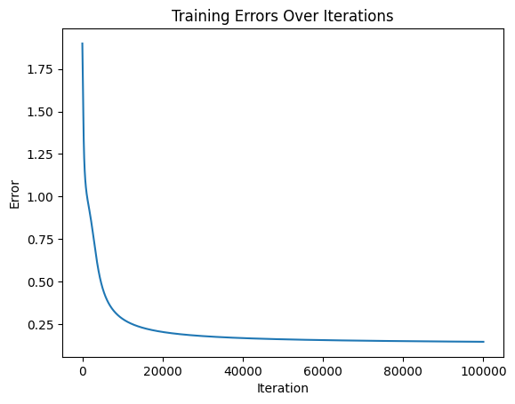

```
-----------------------------------------

Training Accuracy: 98.667%, Validation Accuracy: 96.000%
```

```python
'''
PROVIDE YOUR ANSWER BELOW
-----------------------------------------------------------------------------
Abdullah: Replying to "How well does your network work on the iris dataset?"

Analysis:
In this section, we aim to evaluate the performance of our neural network on
the Iris dataset. We will calculate the accuracy for both the training and
validation sets. Additionally, we will visualize the training errors over
iterations to understand how the network learns from the data.

1. Calculate Accuracy:
   - We will compute the accuracy of the neural network on the training set.
   - Similarly, we will calculate the accuracy on the validation set.

2. Visualize Training Errors:
   - To understand the training process, we will plot the training errors
     over iterations. This will help us observe trends and convergence
     patterns during training.

Let's proceed with these analyses below.
-----------------------------------------------------------------------------
'''

# Calculate accuracy for training set
train_accuracy = np.mean(np.round(y_pred) == np.round(y_train)) * 100

# Calculate accuracy for validation set
(_, _, y_val_pred) = ann(W, X_val, y_val)
val_accuracy = np.mean(np.round(y_val_pred) == np.round(y_val)) * 100

# Plot training errors over iterations
import matplotlib.pyplot as plt

plt.plot(errors)
plt.title("Training Errors Over Iterations")
plt.xlabel("Iteration")
plt.ylabel("Error")
plt.show()

# Display the training and validation accuracies
print("\n-----------------------------------------")
print("\nTraining Accuracy: {:.3f}%, Validation Accuracy: {:.3f}%".format(train_accuracy, val_accuracy))
```

## Part 3. Validation [2pt MODEL]

Validate that the gradients were computed correctly for the 2-layer neural network you developed.

```python
'''
-----------------------------------------------------------------------------
Abdullah: Completed the "TO BE COMPLETED" Parts.
For cleaner output, I am printing only the first five gradients differences.

There are lines to print all the gradients differences which are commented out.
Uncomment those lines to see all the gradients differences.
-----------------------------------------------------------------------------
'''

#write code to numerical verify the gradients you calculated

num_hidden = 5
num_features = 4
num_outputs = 3

#initialize weights
w0 = 2*np.random.random((num_features, num_hidden)) - 1
w1 = 2*np.random.random((num_hidden, num_outputs)) - 1

#combine weights
W = np.array(list(w0.flatten()) + list(w1.flatten()))

#compute gradients analytically
(error, dW, y_pred) = ann(W, X_train, y_train)

#compute gradients numerically
dW_num = np.zeros((len(W),1))

for ind in range(len(W)):
  #reset gradients
  We1 = np.array(list(w0.flatten()) + list(w1.flatten()))
  We2 = np.array(list(w0.flatten()) + list(w1.flatten()))

  #increment slightly
  We1[ind] = + 0.000001
  We2[ind] = - 0.000001

  #compute errors
  (error_e1, dW_e1, y_pred1) = ann(We1, X_train, y_train)
  (error_e2, dW_e2, y_pred2) = ann(We2, X_train, y_train)

  #obtain numerical gradients
  grad_num = (error_e1 - error_e2) / 0.000002

  if ind < 5:
    #display difference between first 5 numerical and analytic gradients
    print(round(abs(grad_num - dW[ind]), 4), grad_num, dW[ind])

  #display difference between all numerical and analytic gradients
  #print(round(abs(grad_num - dW[ind]), 4), grad_num, dW[ind])
```

```
0.7013 -0.27281927528211014 0.4284546752977572
0.3033 -0.14441072848647707 -0.44768060042986824
0.0455 0.03767923528741335 0.08314424133807084
0.296 0.09970218328714253 0.3957372141137704
0.3688 0.021885046663783214 0.3907314922568512
```

# PART B: Cars vs Trucks [30Pt]

In the second part of the assignment we will see how we can use PyTorch to train a neural network to identify Cars and Trucks.

```python
import numpy as np
import time
import torch
import torch.nn as nn
import torch.nn.functional as F
import torch.optim as optim
import torchvision
from torch.utils.data.sampler import SubsetRandomSampler
import torchvision.transforms as transforms
```

## Part 0. Helper Functions

We will be making use of the following helper functions. You will be asked to look at and possibly modify some of these, but you are not expected to understand all of them.

You should look at the function names and read the docstrings. If you are curious, come back and explore the code *after* making some progress on the lab.

```python
###############################################################################
# Data Loading

def get_relevant_indices(dataset, classes, target_classes):
    """ Return the indices for datapoints in the dataset that belongs to the
    desired target classes, a subset of all possible classes.

    Args:
        dataset: Dataset object
        classes: A list of strings denoting the name of each class
        target_classes: A list of strings denoting the name of desired classes
                        Should be a subset of the 'classes'
    Returns:
        indices: list of indices that have labels corresponding to one of the
                 target classes
    """
    indices = []
    for i in range(len(dataset)):
        # Check if the label is in the target classes
        label_index = dataset[i][1] # ex: 9
        label_class = classes[label_index] # ex: 'truck'
        if label_class in target_classes:
            indices.append(i)
    return indices



def get_data_loader(target_classes, batch_size):
    """ Loads images of cars and trucks, splits the data into training, validation
    and testing datasets. Returns data loaders for the three preprocessed datasets.

    Args:
        target_classes: A list of strings denoting the name of the desired
                        classes. Should be a subset of the argument 'classes'
        batch_size: A int representing the number of samples per batch

    Returns:
        train_loader: iterable training dataset organized according to batch size
        val_loader: iterable validation dataset organized according to batch size
        test_loader: iterable testing dataset organized according to batch size
        classes: A list of strings denoting the name of each class
    """

    classes = ('plane', 'car', 'bird', 'cat',
               'deer', 'dog', 'frog', 'horse', 'ship', 'truck')
    ########################################################################
    # The output of torchvision datasets are PILImage images of range [0, 1].
    # We transform them to Tensors of normalized range [-1, 1].
    transform = transforms.Compose(
        [transforms.ToTensor(),
         transforms.Normalize((0.5, 0.5, 0.5), (0.5, 0.5, 0.5))])
    # Load CIFAR10 training data
    trainset = torchvision.datasets.CIFAR10(root='./data', train=True,
                                            download=True, transform=transform)
    # Get the list of indices to sample from
    relevant_indices = get_relevant_indices(trainset, classes, target_classes)

    # Split into train and validation
    np.random.seed(1000) # Fixed numpy random seed for reproducible shuffling
    np.random.shuffle(relevant_indices)
    split = int(len(relevant_indices) * 0.8) #split at 80%

    # split into training and validation indices
    relevant_train_indices, relevant_val_indices = relevant_indices[:split], relevant_indices[split:]
    train_sampler = SubsetRandomSampler(relevant_train_indices)
    train_loader = torch.utils.data.DataLoader(trainset, batch_size=batch_size,
                                               num_workers=1, sampler=train_sampler)
    val_sampler = SubsetRandomSampler(relevant_val_indices)
    val_loader = torch.utils.data.DataLoader(trainset, batch_size=batch_size,
                                              num_workers=1, sampler=val_sampler)
    # Load CIFAR10 testing data
    testset = torchvision.datasets.CIFAR10(root='./data', train=False,
                                           download=True, transform=transform)
    # Get the list of indices to sample from
    relevant_test_indices = get_relevant_indices(testset, classes, target_classes)
    test_sampler = SubsetRandomSampler(relevant_test_indices)
    test_loader = torch.utils.data.DataLoader(testset, batch_size=batch_size,
                                             num_workers=1, sampler=test_sampler)
    return train_loader, val_loader, test_loader, classes

###############################################################################
# Training
def get_model_name(name, batch_size, learning_rate, epoch):
    """ Generate a name for the model consisting of all the hyperparameter values

    Args:
        config: Configuration object containing the hyperparameters
    Returns:
        path: A string with the hyperparameter name and value concatenated
    """
    path = "model_{0}_bs{1}_lr{2}_epoch{3}".format(name,
                                                   batch_size,
                                                   learning_rate,
                                                   epoch)
    return path

def normalize_label(labels):
    """
    Given a tensor containing 2 possible values, normalize this to 0/1

    Args:
        labels: a 1D tensor containing two possible scalar values
    Returns:
        A tensor normalize to 0/1 value
    """
    max_val = torch.max(labels)
    min_val = torch.min(labels)
    norm_labels = (labels - min_val)/(max_val - min_val)
    return norm_labels

def evaluate(net, loader, criterion):
    """ Evaluate the network on the validation set.

     Args:
         net: PyTorch neural network object
         loader: PyTorch data loader for the validation set
         criterion: The loss function
     Returns:
         err: A scalar for the avg classification error over the validation set
         loss: A scalar for the average loss function over the validation set
     """
    total_loss = 0.0
    total_err = 0.0
    total_epoch = 0
    for i, data in enumerate(loader, 0):
        inputs, labels = data
        labels = normalize_label(labels)  # Convert labels to 0/1
        outputs = net(inputs)
        loss = criterion(outputs, labels.float())
        corr = (outputs > 0.0).squeeze().long() != labels
        total_err += int(corr.sum())
        total_loss += loss.item()
        total_epoch += len(labels)
    err = float(total_err) / total_epoch
    loss = float(total_loss) / (i + 1)
    return err, loss

###############################################################################
# Training Curve
def plot_training_curve(path):
    """ Plots the training curve for a model run, given the csv files
    containing the train/validation error/loss.

    Args:
        path: The base path of the csv files produced during training
    """
    import matplotlib.pyplot as plt
    train_err = np.loadtxt("{}_train_err.csv".format(path))
    val_err = np.loadtxt("{}_val_err.csv".format(path))
    train_loss = np.loadtxt("{}_train_loss.csv".format(path))
    val_loss = np.loadtxt("{}_val_loss.csv".format(path))
    plt.title("Train vs Validation Error")
    n = len(train_err) # number of epochs
    plt.plot(range(1,n+1), train_err, label="Train")
    plt.plot(range(1,n+1), val_err, label="Validation")
    plt.xlabel("Epoch")
    plt.ylabel("Error")
    plt.legend(loc='best')
    plt.show()
    plt.title("Train vs Validation Loss")
    plt.plot(range(1,n+1), train_loss, label="Train")
    plt.plot(range(1,n+1), val_loss, label="Validation")
    plt.xlabel("Epoch")
    plt.ylabel("Loss")
    plt.legend(loc='best')
    plt.show()
```

## Part 1. Visualizing the Data

We will make use of some of the CIFAR-10 data set, which consists of colour images of size 32x32 pixels belonging to 10 categories. You can find out more about the dataset at https://www.cs.toronto.edu/~kriz/cifar.html

For this assignment, we will only be using the car and truck categories. We have included code that automatically downloads the dataset the first time that the main script is run.

```python
# This will download the CIFAR-10 dataset to a folder called "data"
# the first time you run this code.
train_loader, val_loader, test_loader, classes = get_data_loader(
    target_classes=["car", "truck"],
    batch_size=1) # One image per batch
```

```
Downloading https://www.cs.toronto.edu/~kriz/cifar-10-python.tar.gz to ./data/cifar-10-python.tar.gz
```

```
Extracting ./data/cifar-10-python.tar.gz to ./data
Files already downloaded and verified
```

### Part (i) [0.5pt EXPLORATORY]

Visualize some of the data by running the code below. Include the visualization in your writeup.

(You don't need to submit anything else.)

[figure not shown]

```python
import matplotlib.pyplot as plt

k = 0
for images, labels in train_loader:
    # since batch_size = 1, there is only 1 image in `images`
    image = images[0]
    # place the colour channel at the end, instead of at the beginning
    img = np.transpose(image, [1,2,0])
    # normalize pixel intensity values to [0, 1]
    img = img / 2 + 0.5
    plt.subplot(3, 5, k+1)
    plt.axis('off')
    plt.imshow(img)

    k += 1
    if k > 14:
        break
```

```python
'''
PROVIDE YOUR ANSWER BELOW
-----------------------------------------------------------------------------
Abdullah:

Replying to "Include the visualization in your writeup."

The visualization displays a 3x5 grid plot, where each row features a
varying number of "cars" and "trucks" from the CIFAR-10 dataset.
Given the exclusive focus on cars and trucks, the figure exclusively
showcases images belonging to these classes.
The presented cars and trucks exhibit diverse types and colors in each row.
The image quality is limited as the pixel size is restricted
to 32x32.
-----------------------------------------------------------------------------
'''
```

### Part (ii) [1pt EXPLORATORY]

How many training examples do we have for the combined `car` and `truck` classes? What about validation examples? What about test examples?

```python
# TO BE COMPLETED
'''
-----------------------------------------------------------------------------
Abdullah:
Calculating the number of training, validation and test examples.
-----------------------------------------------------------------------------
'''
# Number of training examples
num_train_examples = len(train_loader)
print("Number of training examples:", num_train_examples)

# Number of validation examples
num_val_examples = len(val_loader)
print("Number of validation examples:", num_val_examples)

# Number of test examples
num_test_examples = len(test_loader)
print("Number of test examples:", num_test_examples)
```

```
Number of training examples: 8000
Number of validation examples: 2000
Number of test examples: 2000
```

```python
'''
PROVIDE YOUR ANSWER BELOW
-----------------------------------------------------------------------------
Abdullah:

Replying to
"How many training examples do we have for the combined car and truck classes?
What about validation examples?  What about test examples?"

Ans:
Number of training examples: 8000
Number of validation examples: 2000
Number of test examples: 2000

Total 12000 for two categories.

-----------------------------------------------------------------------------
'''
```

## Part 2. Training

We define two neural networks, a `LargeNet` and `SmallNet`. We'll be training the networks in this section.

You won't understand fully what these networks are doing until the next few classes, and that's okay. For this assignment, please focus on learning how to train networks, and how hyperparameters affect training.

```python
class LargeNet(nn.Module):
    def __init__(self):
        super(LargeNet, self).__init__()
        self.name = "large"
        self.conv1 = nn.Conv2d(3, 5, 5)
        self.pool = nn.MaxPool2d(2, 2)
        self.conv2 = nn.Conv2d(5, 10, 5)
        self.fc1 = nn.Linear(10 * 5 * 5, 32)
        self.fc2 = nn.Linear(32, 1)

    def forward(self, x):
        x = self.pool(F.relu(self.conv1(x)))
        x = self.pool(F.relu(self.conv2(x)))
        x = x.view(-1, 10 * 5 * 5)
        x = F.relu(self.fc1(x))
        x = self.fc2(x)
        x = x.squeeze(1) # Flatten to [batch_size]
        return x
```

```python
class SmallNet(nn.Module):
    def __init__(self):
        super(SmallNet, self).__init__()
        self.name = "small"
        self.conv = nn.Conv2d(3, 5, 3)
        self.pool = nn.MaxPool2d(2, 2)
        self.fc = nn.Linear(5 * 7 * 7, 1)

    def forward(self, x):
        x = self.pool(F.relu(self.conv(x)))
        x = self.pool(x)
        x = x.view(-1, 5 * 7 * 7)
        x = self.fc(x)
        x = x.squeeze(1) # Flatten to [batch_size]
        return x
```

```python
small_net = SmallNet()
large_net = LargeNet()
```

### Part (i) [1pt EXPLORATORY]

The methods `small_net.parameters()` and `large_net.parameters()` produces an iterator of all the trainable parameters of the network. These parameters are torch tensors containing many scalar values.

We haven't learned how how the parameters in these high-dimensional tensors will be used, but we should be able to count the number of parameters. Measuring the number of parameters in a network is one way of measuring the "size" of a network.

What is the total number of parameters in `small_net` and in `large_net`? (Hint: how many numbers are in each tensor?)

```python
for param in small_net.parameters():
    print(param.shape)
```

```
torch.Size([5, 3, 3, 3])
torch.Size([5])
torch.Size([1, 245])
torch.Size([1])
```

```python
# TO BE COMPLETED

'''
-----------------------------------------------------------------------------
Abdullah:

Calculating the number of parameters for the networks using numel() function
from torch
-----------------------------------------------------------------------------

'''
total_params_small_net = sum(p.numel() for p in small_net.parameters())
print("Total number of parameters in SmallNet:", total_params_small_net)

total_params_large_net = sum(p.numel() for p in large_net.parameters())
print("Total number of parameters in LargeNet:", total_params_large_net)
```

```
Total number of parameters in SmallNet: 386
Total number of parameters in LargeNet: 9705
```

```python
'''
PROVIDE YOUR ANSWER BELOW
-----------------------------------------------------------------------------
Abdullah:

Replying to "What is the total number of parameters in
small_net and in large_net? "

Ans:
Total number of parameters in SmallNet: 386
Total number of parameters in LargeNet: 9705
-----------------------------------------------------------------------------

'''
```

### The function train_net

The function `train_net` below takes an untrained neural network (like `small_net` and `large_net`) and several other parameters. You should be able to understand how this function works. The figure below shows the high level training loop for a machine learning model:

[figure not shown]

```python
def train_net(net, batch_size=64, learning_rate=0.01, num_epochs=30):
    ########################################################################
    # Train a classifier on cars vs trucks
    target_classes = ["car", "truck"]
    ########################################################################
    # Fixed PyTorch random seed for reproducible result
    torch.manual_seed(1000)
    ########################################################################
    # Obtain the PyTorch data loader objects to load batches of the datasets
    train_loader, val_loader, test_loader, classes = get_data_loader(
            target_classes, batch_size)
    ########################################################################
    # Define the Loss function and optimizer
    # The loss function will be Binary Cross Entropy (BCE). In this case we
    # will use the BCEWithLogitsLoss which takes unnormalized output from
    # the neural network and scalar label.
    # Optimizer will be SGD with Momentum.
    criterion = nn.BCEWithLogitsLoss()
    optimizer = optim.SGD(net.parameters(), lr=learning_rate, momentum=0.9)
    ########################################################################
    # Set up some numpy arrays to store the training/test loss/erruracy
    train_err = np.zeros(num_epochs)
    train_loss = np.zeros(num_epochs)
    val_err = np.zeros(num_epochs)
    val_loss = np.zeros(num_epochs)
    ########################################################################
    # Train the network
    # Loop over the data iterator and sample a new batch of training data
    # Get the output from the network, and optimize our loss function.
    start_time = time.time()
    for epoch in range(num_epochs):  # loop over the dataset multiple times
        total_train_loss = 0.0
        total_train_err = 0.0
        total_epoch = 0
        for i, data in enumerate(train_loader, 0):
            # Get the inputs
            inputs, labels = data
            labels = normalize_label(labels) # Convert labels to 0/1
            # Zero the parameter gradients
            optimizer.zero_grad()
            # Forward pass, backward pass, and optimize
            outputs = net(inputs)
            loss = criterion(outputs, labels.float())
            loss.backward()
            optimizer.step()
            # Calculate the statistics
            corr = (outputs > 0.0).squeeze().long() != labels
            total_train_err += int(corr.sum())
            total_train_loss += loss.item()
            total_epoch += len(labels)
        train_err[epoch] = float(total_train_err) / total_epoch
        train_loss[epoch] = float(total_train_loss) / (i+1)
        val_err[epoch], val_loss[epoch] = evaluate(net, val_loader, criterion)
        print(("Epoch {}: Train err: {}, Train loss: {} |"+
               "Validation err: {}, Validation loss: {}").format(
                   epoch + 1,
                   train_err[epoch],
                   train_loss[epoch],
                   val_err[epoch],
                   val_loss[epoch]))
        # Save the current model (checkpoint) to a file
        model_path = get_model_name(net.name, batch_size, learning_rate, epoch)
        torch.save(net.state_dict(), model_path)
    print('Finished Training')
    end_time = time.time()
    elapsed_time = end_time - start_time
    print("Total time elapsed: {:.2f} seconds".format(elapsed_time))
    # Write the train/test loss/err into CSV file for plotting later
    epochs = np.arange(1, num_epochs + 1)
    np.savetxt("{}_train_err.csv".format(model_path), train_err)
    np.savetxt("{}_train_loss.csv".format(model_path), train_loss)
    np.savetxt("{}_val_err.csv".format(model_path), val_err)
    np.savetxt("{}_val_loss.csv".format(model_path), val_loss)
```

### Part (ii) [0.5pt EXPLORATORY]

The parameters to the function `train_net` are hyperparameters of our neural network. We made these hyperparameters easy to modify so that we can tune them later on.

What are the default values of the parameters `batch_size`, `learning_rate`, and `num_epochs`?

```python
'''
PROVIDE YOUR ANSWER BELOW
-----------------------------------------------------------------------------
Abdullah:
Replying to "What are the default values of the parameters batch_size,
learning_rate, and num_epochs?"

Ans:
The default values for the parameters batch_size, learning_rate,
and num_epochs in the train_net function are as follows:

batch_size: 64
learning_rate: 0.01
num_epochs: 30
-----------------------------------------------------------------------------

'''
```

### Part (iii) [0.5pt EXPLORATORY]

What files are written to disk when we call `train_net` with `small_net`, and train for 5 epochs? Provide a list of all the files written to disk, and what information the files contain.

```python
'''
-----------------------------------------------------------------------------

Abdullah:
<Added extra cell for running the code>

Running the code with small_net to observe the saved files. Since we only
have to change the number of epochs, the rest of the values will be default.
-----------------------------------------------------------------------------
'''
small_net = SmallNet()

# Train small_net for 5 epochs
train_net(small_net, num_epochs=5)
```

```
Files already downloaded and verified
Files already downloaded and verified
Epoch 1: Train err: 0.360125, Train loss: 0.6316153569221497 |Validation err: 0.343, Validation loss: 0.6170654203742743
Epoch 2: Train err: 0.31475, Train loss: 0.5952979040145874 |Validation err: 0.3165, Validation loss: 0.593736719340086
Epoch 3: Train err: 0.29775, Train loss: 0.577410436630249 |Validation err: 0.293, Validation loss: 0.5753874285146594
Epoch 4: Train err: 0.283875, Train loss: 0.5598477594852448 |Validation err: 0.284, Validation loss: 0.5566486734896898
Epoch 5: Train err: 0.2735, Train loss: 0.5455854947566986 |Validation err: 0.284, Validation loss: 0.5537397488951683
Finished Training
Total time elapsed: 21.44 seconds
```

```python
'''
PROVIDE YOUR ANSWER BELOW
-----------------------------------------------------------------------------

Abdullah:
Replying to

"What files are written to disk when we call train_net with
small_net, and train for 5 epochs? Provide a list of all the files written to
disk, and what information the files contain."

Ans:

Saved files names:

model_small_bs64_lr0.01_epoch0
model_small_bs64_lr0.01_epoch1
model_small_bs64_lr0.01_epoch2
model_small_bs64_lr0.01_epoch3
model_small_bs64_lr0.01_epoch4
model_small_bs64_lr0.01_epoch4_train_err.csv
model_small_bs64_lr0.01_epoch4_train_loss.csv
model_small_bs64_lr0.01_epoch4_val_err.csv
model_small_bs64_lr0.01_epoch4_val_loss.csv

____________________________________________________________________________

The files named model_small_bs64_lr0.01_epoch0 to
model_small_bs64_lr0.01_epoch4 represent checkpoints
(saved values of model weights) of the trained neural network at the end
of each epoch. These files contain the learned parameters of the network at the
respective epochs, allowing you to resume training or perform inference
without starting from scratch. The naming convention also mentiones batch size
and learning rate as well. bs = batch size and lr = learning rate

model_small_bs64_lr0.01_epoch4_train_err.csv: Training error per epoch
model_small_bs64_lr0.01_epoch4_train_loss.csv: Training loss per epoch
model_small_bs64_lr0.01_epoch4_val_err.csv: Validation error per epoch
model_small_bs64_lr0.01_epoch4_val_loss.csv: Validation loss per epoch

-----------------------------------------------------------------------------

'''
```

### Part (iv) [0.5pt EXPLORATORY]

Train both `small_net` and `large_net` using the function `train_net` and its default parameters. The function will write many files to disk, including a model checkpoint (saved values of model weights) at the end of each epoch.

If you are using Google Colab, you will need to mount Google Drive so that the files generated by `train_net` gets saved. We will be using these files in the parts that follow. (See the Google Colab tutorial for more information about this.)

Report the total time elapsed when training each network. Which network took longer to train? Why?

```python
# Since the function writes files to disk, you will need to mount
# your Google Drive. If you are working on the assignment locally, you
# can comment out this code.

from google.colab import drive
drive.mount('/content/gdrive')
```

```python
# TO BE COMPLETED

'''
-----------------------------------------------------------------------------

Abdullah: Code for
"Report the total time elapsed when training each network.
Which network took longer to train? Why?"

Ans:
For this part, I am calling train_net function with both (small and large)
networks. After the code is executed different information will be provided
including time taken.
-----------------------------------------------------------------------------
'''
small_net = SmallNet()
# Train Small Net
train_net(small_net)

large_net = LargeNet()
# Train Large Net
train_net(large_net)
```

```
Files already downloaded and verified
Files already downloaded and verified
Epoch 1: Train err: 0.36675, Train loss: 0.6353887991905213 |Validation err: 0.3415, Validation loss: 0.6150007527321577
Epoch 2: Train err: 0.308875, Train loss: 0.5826559357643127 |Validation err: 0.2875, Validation loss: 0.564431675709784
Epoch 3: Train err: 0.264875, Train loss: 0.5382705183029175 |Validation err: 0.254, Validation loss: 0.5179520631209016
Epoch 4: Train err: 0.248625, Train loss: 0.5110255150794983 |Validation err: 0.244, Validation loss: 0.49379982240498066
Epoch 5: Train err: 0.2145, Train loss: 0.46676650977134704 |Validation err: 0.219, Validation loss: 0.4612079197540879
Epoch 6: Train err: 0.205375, Train loss: 0.4499680604934692 |Validation err: 0.2155, Validation loss: 0.46056494768708944
Epoch 7: Train err: 0.196375, Train loss: 0.4287906076908112 |Validation err: 0.203, Validation loss: 0.4401447931304574
Epoch 8: Train err: 0.185875, Train loss: 0.41471759414672854 |Validation err: 0.191, Validation loss: 0.4304955182597041
Epoch 9: Train err: 0.18325, Train loss: 0.4108460035324097 |Validation err: 0.2045, Validation loss: 0.4501950591802597
Epoch 10: Train err: 0.18425, Train loss: 0.4030822279453278 |Validation err: 0.1925, Validation loss: 0.41391456220299006
Epoch 11: Train err: 0.169875, Train loss: 0.3865358200073242 |Validation err: 0.189, Validation loss: 0.4081690199673176
Epoch 12: Train err: 0.17, Train loss: 0.3822174071073532 |Validation err: 0.1815, Validation loss: 0.42059643333777785
Epoch 13: Train err: 0.167875, Train loss: 0.3796561441421509 |Validation err: 0.1945, Validation loss: 0.4209387172013521
Epoch 14: Train err: 0.157875, Train loss: 0.3680064479112625 |Validation err: 0.1975, Validation loss: 0.43060743901878595
Epoch 15: Train err: 0.166, Train loss: 0.37470442306995394 |Validation err: 0.18, Validation loss: 0.4082612143829465
Epoch 16: Train err: 0.156625, Train loss: 0.3596054652929306 |Validation err: 0.1765, Validation loss: 0.39841766096651554
Epoch 17: Train err: 0.1535, Train loss: 0.3597384506464005 |Validation err: 0.1745, Validation loss: 0.3956174133345485
Epoch 18: Train err: 0.157375, Train loss: 0.3642198351621628 |Validation err: 0.185, Validation loss: 0.42031767778098583
Epoch 19: Train err: 0.156, Train loss: 0.35710543406009676 |Validation err: 0.176, Validation loss: 0.4035742003470659
Epoch 20: Train err: 0.150375, Train loss: 0.35176943957805634 |Validation err: 0.1855, Validation loss: 0.42455665301531553
Epoch 21: Train err: 0.156125, Train loss: 0.35567858517169954 |Validation err: 0.1785, Validation loss: 0.4065138902515173
Epoch 22: Train err: 0.14825, Train loss: 0.3501549125909805 |Validation err: 0.1785, Validation loss: 0.40343587566167116
Epoch 23: Train err: 0.153375, Train loss: 0.3538445826768875 |Validation err: 0.174, Validation loss: 0.39249278977513313
Epoch 24: Train err: 0.15025, Train loss: 0.3505782083272934 |Validation err: 0.182, Validation loss: 0.41654352098703384
Epoch 25: Train err: 0.153375, Train loss: 0.3542488791942596 |Validation err: 0.1775, Validation loss: 0.40417609456926584
Epoch 26: Train err: 0.1555, Train loss: 0.354605351805687 |Validation err: 0.18, Validation loss: 0.40522398706525564
Epoch 27: Train err: 0.146875, Train loss: 0.3490990217924118 |Validation err: 0.2025, Validation loss: 0.44889105297625065
Epoch 28: Train err: 0.14825, Train loss: 0.34945000302791596 |Validation err: 0.169, Validation loss: 0.3952301936224103
Epoch 29: Train err: 0.147375, Train loss: 0.3450049192905426 |Validation err: 0.184, Validation loss: 0.4108818303793669
Epoch 30: Train err: 0.15425, Train loss: 0.35580321204662324 |Validation err: 0.171, Validation loss: 0.38879405008628964
Finished Training
Total time elapsed: 135.79 seconds
Files already downloaded and verified
Files already downloaded and verified
Epoch 1: Train err: 0.410625, Train loss: 0.6796574716567994 |Validation err: 0.3755, Validation loss: 0.6593774873763323
Epoch 2: Train err: 0.342625, Train loss: 0.6225734875202179 |Validation err: 0.3275, Validation loss: 0.6066484097391367
Epoch 3: Train err: 0.297375, Train loss: 0.5702565081119537 |Validation err: 0.262, Validation loss: 0.5392701840028167
Epoch 4: Train err: 0.23725, Train loss: 0.4967639360427856 |Validation err: 0.206, Validation loss: 0.4584508975967765
```

[output cut: 13 more lines]

```
Epoch 18: Train err: 0.079375, Train loss: 0.20253798991441727 |Validation err: 0.141, Validation loss: 0.3339142808690667
Epoch 19: Train err: 0.08175, Train loss: 0.20329145282506944 |Validation err: 0.1265, Validation loss: 0.32901091035455465
Epoch 20: Train err: 0.071875, Train loss: 0.18083464801311494 |Validation err: 0.148, Validation loss: 0.35305273393169045
Epoch 21: Train err: 0.06675, Train loss: 0.169170505464077 |Validation err: 0.14, Validation loss: 0.35680252872407436
Epoch 22: Train err: 0.064125, Train loss: 0.16335252618789672 |Validation err: 0.1255, Validation loss: 0.32694318355061114
Epoch 23: Train err: 0.066875, Train loss: 0.16831049436330794 |Validation err: 0.1365, Validation loss: 0.33463054383173585
Epoch 24: Train err: 0.056625, Train loss: 0.14657563745975494 |Validation err: 0.129, Validation loss: 0.3362488350830972
Epoch 25: Train err: 0.047, Train loss: 0.12846827962994575 |Validation err: 0.1205, Validation loss: 0.3545698490925133
Epoch 26: Train err: 0.051375, Train loss: 0.1322926723957062 |Validation err: 0.127, Validation loss: 0.36078582308255136
Epoch 27: Train err: 0.046375, Train loss: 0.12138465791940689 |Validation err: 0.1475, Validation loss: 0.3906209929846227
Epoch 28: Train err: 0.03725, Train loss: 0.10010284277796745 |Validation err: 0.119, Validation loss: 0.3792589318472892
Epoch 29: Train err: 0.035, Train loss: 0.09213039453327655 |Validation err: 0.148, Validation loss: 0.4685916667804122
Epoch 30: Train err: 0.035, Train loss: 0.09333992889523506 |Validation err: 0.1385, Validation loss: 0.4297151667997241
Finished Training
Total time elapsed: 149.03 seconds
```

```python
'''
PROVIDE YOUR ANSWER BELOW

-----------------------------------------------------------------------------
Abdullah: Replying to
"Report the total time elapsed when training each network.
Which network took longer to train? Why?"

SmallNet:  Total time elapsed: 135.79 seconds
LargeNet: Total time elapsed: 149.03 seconds


In this case, LargeNet took longer to train compared to SmallNet. The reason
for this could be the architectural differences between the two networks.
LargeNet has more parameters and a higher level of complexity in its
architecture compared to SmallNet. Moreover, if we compare the code for setting
up the network, we can see that the LargeNet has more layers than Smallnet.
Generally, larger networks may require more computation and time to train.

Note: Since these codes are running on Google Colab, one big factor is the
resource allocation from Colab at a specific time. We might see a difference
in elapsed time if we run train networks over and over.
-----------------------------------------------------------------------------

'''
```